# Advanced R Final Project

Sibi Simon

1 September 2019

### Dataset

The dataset consist of details of all discovered extra-solar planets. The details of columns are described below.

1: Primary identifier of planet 2: Binary flag [0=no known stellar binary companion; 1=P-type binary (circumbinary); 2=S-type binary; 3=orphan planet (no star)] 3: Planetary mass [Jupiter masses] 4: Radius [Jupiter radii] 5: Period [days] 6: Semi-major axis [Astronomical Units] 7: Eccentricity 8: Periastron [degree] 9: Longitude [degree] 10: Ascending node [degree] 11: Inclination [degree] 12: Surface or equilibrium temperature [K] 13: Age [Gyr] 14: Discovery method 15: Discovery year [yyyy] 16: Last updated [yy/mm/dd] 17: Right ascension [hh mm ss] 18: Declination [+/-dd mm ss] 19: Distance from Sun [parsec] 20: Host star mass [Solar masses] 21: Host star radius [Solar radii] 22: Host star metallicity [log relative to solar] 23: Host star temperature [K] 24: Host star age [Gyr] 25: A list of lists the planet is on

### Question 1

```r
# Reading data using read_csv function
exoplanet_data = read_csv("exo_data.csv")

# Converting columns to approproate type as mentioned
exoplanet_data %<>% mutate(year = as.integer(year), meth = as.factor(meth), flag = as.factor(flag))
```

### Question 2

```r
# Avoiding the exoplanet  with unknown method of discovery
exoplanet_data %<>% filter(!is.na(meth))
```

### Question 3

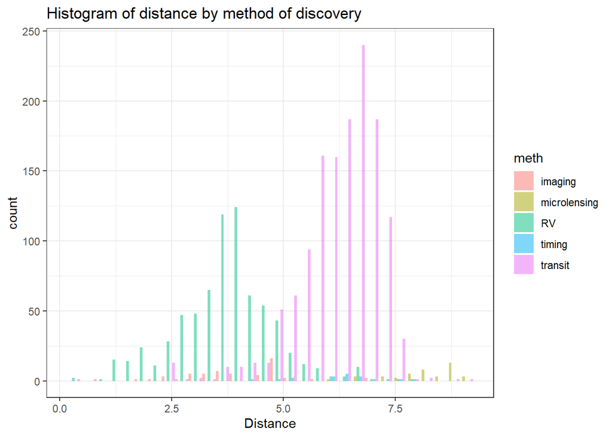

```r
# Using ggplot to plot histogram of log distance highlighted by nethod of discovery
ggplot(exoplanet_data, aes(x=log(dist), fill=meth)) +
  geom_histogram(alpha = 0.5, position="dodge") +
  labs(title="Histogram of distance by method of discovery", x = "Distance") +
  theme_bw()
```

### Question 4

```r
# Adding the additional column to dataset containig the url to route when clicked
# Url will be base url + id
exoplanet_data$onclick =  sprintf("window.open(\"%s%s\")",
                        "http://www.openexoplanetcatalogue.com/planet/",
                         as.character(exoplanet_data$id))

# Ploting log distance vs log mass scatterplot and adding interactive feature to it
# The plot is seperated based on the method of discovery
gg_planet = ggplot(exoplanet_data, aes(x = log(dist),
                    y = log(mass), color = meth)) +
                    geom_point_interactive(aes(data_id = id,
                    tooltip = id, onclick = onclick)) +                # Adding interactive point
                    facet_grid(. ~ meth, scales = 'free_x') +          # Seperating by method
                    labs(title="Distance vs Mass scatter plot",        # Adding labels
                         x = "Distance", y="Mass") +
                    theme_bw() +                                       # Selecting theme
                    theme(legend.position = 'None')                    # Removing legend

# Adding hover and interactive feature
ggiraph(code = print(gg_planet))
```

[interactive chart not shown]

### Question 5

```r
# Rename the column name radius into jupiter_radius
exoplanet_data <- rename(exoplanet_data, jupiter_radius = 'radius')

# Computing earth radius
exoplanet_data$earth_radius <- exoplanet_data$jupiter_radius * 11.2
```

### Question 6

```r
# Filtering data without NA values in period and earth radius column
exo_planet_data_cluster <- exoplanet_data[complete.cases(exoplanet_data[, c("period", "earth_radius")]),]

# Data with NA in period and earth_radius
exo_planet_data_with_na <- exoplanet_data[!complete.cases(exoplanet_data[, c("period", "earth_radius")]),]

# Clustering using kmeans with 4 centers and nstart 15
km_cl <- kmeans(log(exo_planet_data_cluster %>% select(period, earth_radius)),
                4, nstart = 15)
```

Here N start 15 is given to converge to global minima rather than the local minima which will give better result than just running once.

### Question 7

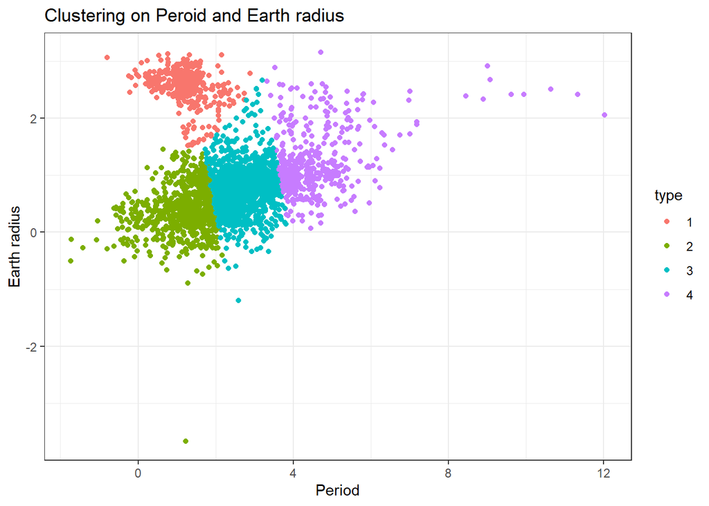

```r
# Adding cluster as a column in dataset
exo_planet_data_cluster$type <- km_cl$cluster
# Converting to factor
exo_planet_data_cluster$type <- as.factor(exo_planet_data_cluster$type)

# Plotting the clustered data
ggplot(data=exo_planet_data_cluster,
       aes(x=log(period), y=log(earth_radius), color=type)) +
       geom_point() + labs(title="Clustering on Peroid and Earth radius",
                            x = "Period", y="Earth radius") +            # Adding labels
       theme_bw()                                                        # Adding theme
```

```r
# Adding an additional factor unknown to type column NA dataset created above
exo_planet_data_with_na$type <- 'unknown'
```

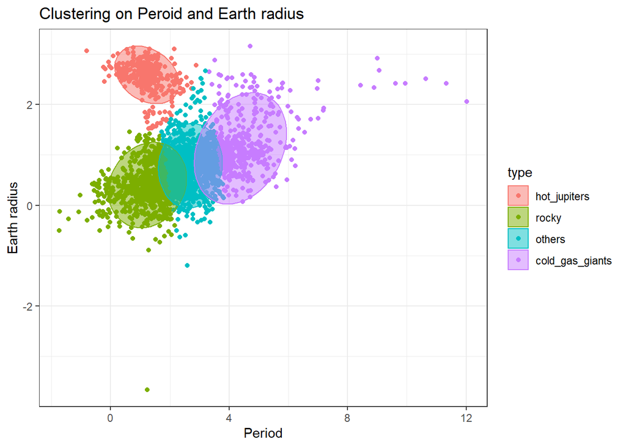

```r
# Since we are setting the seed the levels will be in the same order
levels(exo_planet_data_cluster$type) <- c('hot_jupiters', 'rocky', 'others', 'cold_gas_giants')

# Cluster plot with labels
ggplot(data=exo_planet_data_cluster, aes(x=log(period), y=log(earth_radius), color=type)) +
  geom_point() +                                                        # Adding points
  stat_ellipse(geom = "polygon", alpha = 1/2, aes(fill = type)) +       # Drawing ellipse around clusters
  labs(title="Clustering on Peroid and Earth radius",
              x = "Period", y="Earth radius") +                         # Adding labels
  theme_bw()                                                            # Adding theme
```

### Question 8

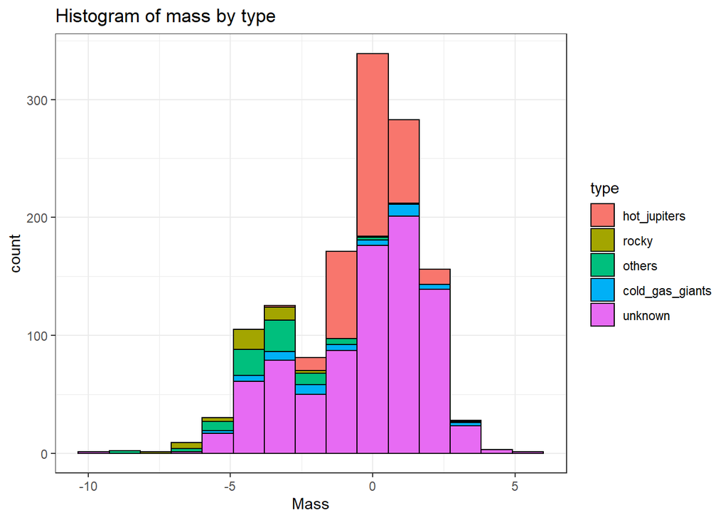

```r
# Binding the two dataset (data used for cluster and data with type unknown) to single one to avoid data loss
exoplanet_cmplt_data <- rbind(exo_planet_data_cluster, exo_planet_data_with_na)

# Histogram plot
ggplot(exoplanet_cmplt_data, aes(x=log(mass), fill=type)) +
  geom_histogram(bins=15, colour='black') +                         # Histogram
  labs(title="Histogram of mass by type", x = "Mass") +             # Adding labels
  theme_bw()                                                        # Adding theme
```

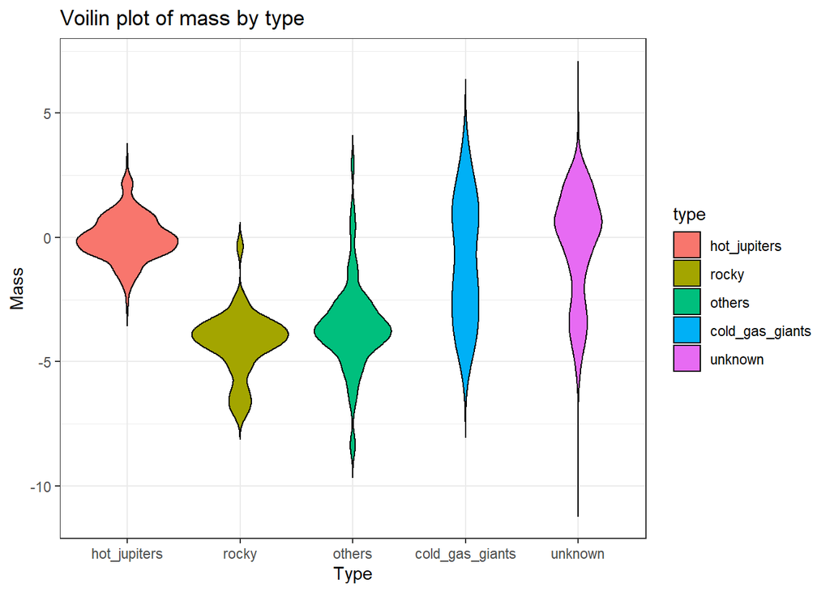

```r
# Voilin plot
ggplot(exoplanet_cmplt_data, aes(x=type, y=log(mass), fill=type)) +
  geom_violin(trim=FALSE,  color="black")+
  labs(title="Voilin plot of mass by type",x="Type", y = "Mass")+   # Adding labels
  theme_bw()                                                        # Adding theme
```

### Question 9

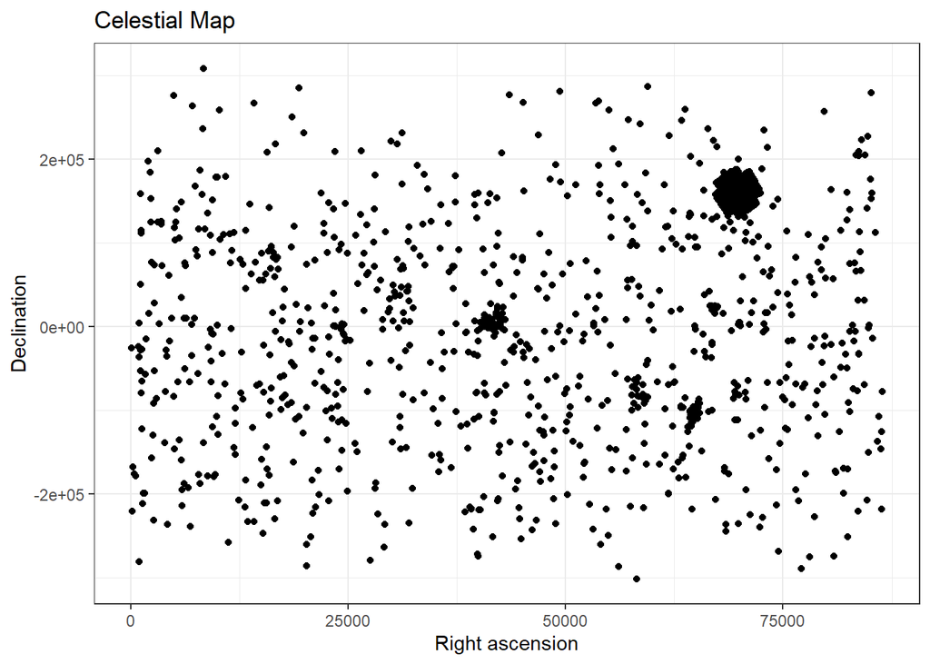

```r
# Functing for finding the total seconds value given the a string
find_second_val <- function(time){
  as.numeric(time[1]) * 3600 + as.numeric(time[2]) * 60 + as.numeric(time[3])
}

# Splitting the r_asc and decl column with space along each row and applying converting function
r_asc = lapply(strsplit(exoplanet_cmplt_data$r_asc, " "), find_second_val)
decl = lapply(strsplit(exoplanet_cmplt_data$decl, " "), find_second_val)

# Creating tibble with the two columns
celestial_data = tibble(r_asc=unlist(r_asc), decl=unlist(decl))

# Scatter plot between the tansformed data
ggplot(
  celestial_data,
  aes(r_asc, decl)) +
  geom_point() +                                                         # Adding points
  labs(title="Celestial Map",x="Right ascension", y = "Declination") +   # Adding labels
  theme_bw()                                                             # Adding theme
```

### Question 10

[figure not shown]

```r
# Creating time series data
# Getting group by frequency
time_series_data = exoplanet_cmplt_data %>% group_by(meth, year) %>% summarise(Freq=n()) %>% na.omit()

# Finding cumulative frequency up to that year
time_series_data %<>% group_by(meth) %>% mutate(cum_freq = cumsum(Freq))

# Time series plot for exoplanet discovered till year
ggplot(
  time_series_data,
  aes(year, cum_freq, color=meth)) +
  geom_line(size=1.5) +
  labs(title = 'Times series plot for exoplanet discoverd',
       x = 'Year', y = 'Frequency of exoplanet discovered till year') +               # Adding labels
  transition_reveal(year) +                                                           # Time series line
  theme_bw()                                                                          # Adding theme
```

### Question 11

```r
# Define UI for application that draws a histogram
ui <- fluidPage(

   # Application title
   titlePanel("Exoplanet Scatterplot"),


   # Sidebar with a slider input for year and drop down menu for selecting exoplanet type
   sidebarLayout(
      sidebarPanel(
         helpText("Filter data by selecting year and type of exoplanet"),
         sliderInput("year",
                     "Select Year:",
                     min = 2009,
                     max = 2018,
                     value = 2018,
                     sep=""),
         selectInput("type", "Select Type:",
                     choices = list("All" = "all", "Hot Jupiters" = "hot_jupiters",
                                    "Rocky" = "rocky", "Cold Gas Giants" = "cold_gas_giants",
                                    "Unknown" = "unknown"), selected = "all")
      ),

      # Show a plot of the generated distribution
      mainPanel(
         plotOutput("distPlot")
      )
   )
)

# Define server logic required to draw a scatter plot
server <- function(input, output) {

   output$distPlot <- renderPlot({

      # Filtering data according to the year
      filter_data <- exoplanet_cmplt_data %>% filter(year == input$year)

      # Checking if the type is all if yes plotting all points
      if (input$type == "all") {
        ggplot(filter_data, aes(x=log(mass), y=log(dist), color=type)) +
          geom_point() +
          labs(title = "Mass Vs Distance Scatter Plot", x="Mass", y="Distance") +
          theme_bw()
      }

      # If type is selected filtering data according to the corresponding type
      else {
        plt_title <- paste("Mass Vs Distance scatter plot for", input$type)
        filter_data <- exoplanet_cmplt_data %>% filter(year == input$year, type == input$type)
        ggplot(filter_data, aes(x=log(mass), y=log(dist))) +
          geom_point() +
          labs(title = plt_title, x="Mass", y="Distance") +
          theme_bw()
      }
   })
}

# Run the application
shinyApp(ui = ui, server = server)
```

Shiny applications not supported in static R Markdown documents

### Question 12